# MSD 2019 Final Project

A replication and extension of “Wage disparity and team productivity: evidence from Major League Baseball” by Craig A. Depken II, 1999

Forrest Hofmann (fhh2112) & Sagar Lal (sl3946)

2019-05-10 13:12:52

# 1 Introduction

## 1.1 Problem and Paper Description

Our goal was to replicate and extend the results seen in “Wage disparity and team productivity: evidence from major league baseball” by Craig A. Depken II. Depken’s paper explores how disparity impacts a team’s performance. He examines this in the context of baseball where there are standard measures of both performance (team win percentage) and wages (annual player salaries). He evaluates his results with respect to two previous hypotheses: the danger-potential hypothesis, which suggests that wage disparity indicates complementary skills of team members and thus positively impacts performance, and the team-cohesiveness theory, which suggests that wage disparity creates dysfunction and thus negatively impacts performance.

## 1.2 Problem Motivation

There has been a longstanding debate over how baseball franchises should be run. Should teams prioritize signing star players, or should teams focus on the overall depth and quality of the roster as a whole? In recent news, Bryce Harper, Manny Machado, and Mike Trout have all signed 10+ year, $300+ million dollar contracts before the 2019 season. These events have brought this debate back into the spotlight.

## 1.3 Data Source

The data is taken from Sean Lahman’s baseball database, up to date as of 2019. The database is the most commonly used archive for baseball statistics. The latest version of the data can be accessed at http://www.seanlahman.com/baseball-archive/statistics.

# 2 Reproduction

## 2.1 Reproduction Notes

We faced a couple of challenges when considering the context of the data.

First, the original paper did not describe how time fixed effects were accounted for. For example, one may choose to control for different expansion periods or different years. When experimenting with different regression formulas, we found that controlling for different years yielded results most similar to those of the original paper.

## 2.2 Reproduction Code and Analysis

Read in the data.

```r
teams <- read_csv(here('data/teams.csv'))
salaries <- read_csv(here('data/salaries.csv'))
```

```r
teams$WSWin <- as.logical(teams$WSWin == 'Y')
teams <- teams %>%
  filter(1985 <= yearID & yearID <= 2016) %>%
  mutate(winPercentage = W / (W + L) * 1000) %>%
  filter(yearID != 1987 & teamID != 'TEX')

salaries <- salaries %>%
  filter(1985 <= yearID & yearID <= 2016) %>%
  mutate(salaryMil = salary / 1000000) %>%
  filter(yearID != 1987 & teamID != 'TEX')
```

Compute total team salaries, measured in millions of dollars.

```r
teams <- teams %>%
  inner_join(salaries) %>%
  group_by(yearID, teamID, G, W, L, WSWin, winPercentage) %>%
  summarize(totalSalaryMil = sum(salaryMil))
```

Compute the salary share of each player on their respective team for each year.

```r
salaries <- salaries %>%
  inner_join(teams) %>%
  mutate(salaryShare = salaryMil / totalSalaryMil * 100) %>%
  mutate(salaryShareSquared = salaryShare ^ 2) %>%
  select(yearID, teamID, playerID, salary, salaryShare, salaryShareSquared)
```

Compute the Herfindahl-Hirschman Index for each team’s salary. For more information, see https://en.wikipedia.org/wiki/Herfindahl_index. The index ranges from 0 to 10,000 where smaller values represent more equality and larger values represent more inequality.

```r
teams <- teams %>%
  inner_join(salaries) %>%
  group_by(yearID, teamID, G, W, L, winPercentage, WSWin, totalSalaryMil) %>%
  summarize(HHI = sum(salaryShareSquared))
```

Take the subset of the data from the years 1985 to 1998, inclusive, to match Depken’s analysis.

```r
teams_old <- teams %>%
  filter(1985 <= yearID & yearID <= 1998) %>%
  mutate(normalizedYear = yearID - 1985)
```

View the summary statistics of win percentage, total team salary, and team HHI for the subset of data.

```r
summary(teams_old$winPercentage)
```

```
##    Min. 1st Qu.  Median    Mean 3rd Qu.    Max.
##   327.2   456.8   496.9   500.1   543.2   703.7
```

```r
sd(teams_old$winPercentage)
```

```
## [1] 67.34053
```

```r
summary(teams_old$totalSalaryMil)
```

```
##    Min. 1st Qu.  Median    Mean 3rd Qu.    Max.
##   4.613  14.217  23.655  26.220  37.022  72.356
```

```r
sd(teams_old$totalSalaryMil)
```

```
## [1] 14.00647
```

```r
summary(teams_old$HHI)
```

```
##    Min. 1st Qu.  Median    Mean 3rd Qu.    Max.
##   427.5   666.8   754.7   801.5   876.3  2158.3
```

```r
sd(teams_old$HHI)
```

```
## [1] 220.2525
```

Our reproduction of summary statistics shows results that are nearly identical to the original paper. In particular, we see the same values for win percentage, with slight differences only due to rounding. Note that are values are simply scaled differently. Our total salary numbers are higher across minimum, mean, and maximum. We also see slightly different values for HHI. Our hypothesis for these differences can be seen in the notes section above. Moreover, there are likely slight differences between our data set and the one used in the original paper. We are confident in our calculation of the metrics given that our maximum HHI is identical to that in the original paper.

Run the fixed effects regression on data between 1985 and 1998, inclusive.

```r
hhi_fixed_old <- lm(formula = winPercentage ~ totalSalaryMil + HHI + normalizedYear +
                                              teamID + 0,
                    data = teams_old)
summary(hhi_fixed_old)$coefficients[1:3,]
```

```
##                   Estimate Std. Error   t value     Pr(>|t|)
## totalSalaryMil  1.96115149 0.48091620  4.077948 5.803436e-05
## HHI            -0.04611478 0.02028827 -2.272977 2.372293e-02
## normalizedYear -4.08667575 1.76297250 -2.318060 2.110738e-02
```

Our regression results match the paper’s regression results in terms of coefficients being of the same order of magnitude and sign. Notably, both show that wage disparity negatively impacts team performance, which supports the team-cohesiveness theory. The difference in coefficients is that our regression claims that every additional $1 million spent improves win percentage by approximately 0.20%, while the paper claims this amount to be 0.17%. In addition, each additional year in time corresponds to a 0.41% drop in win percentage, compared to 0.26% in the original paper. Note that the interpretation for the effect of time on win percentage should not be taken literally. Instead, the negative relationship here suggests that equal amounts of expenditure are worth less in terms of win percentage as time goes on. It is encouraging that the HHI index coefficients are quite similar. Here, we obtain a coefficient of -0.046, while the original paper obtains a coefficient of -0.064.

Run the random effects regression on data between 1985 and 1998, inclusive.

```r
hhi_random_old <- lm(formula = winPercentage ~ totalSalaryMil + HHI + normalizedYear,
                     data = teams_old)
summary(hhi_random_old)$coefficients[1:4,]
```

```
##                   Estimate  Std. Error   t value      Pr(>|t|)
## (Intercept)    515.9993052 15.18582553 33.979009 1.416422e-110
## totalSalaryMil   2.1067707  0.41153306  5.119323  5.180395e-07
## HHI             -0.0469241  0.01853488 -2.531665  1.180894e-02
## normalizedYear  -4.7782865  1.57044613 -3.042630  2.530509e-03
```

We see similar results when replicating the random effects model, which doesn’t have team specific intercepts. It is notable that the relative changes in coefficients between our fixed and random effects regressions are very similar to that of the original paper. Our coefficients for salary and year increase in magnitude, while our coefficient for HHI remains almost identical. One odd note is that both our intercept and the original paper’s intercept suggest a default win percentage of greater than .500 or 50%.

# 3 Extension

## 3.1 Extension Motivation

Given the paper’s lack of visualizations of the underlying data, we thought it was important to create several graphs to help readers understand the data, its distribution, and the various trends over time. Our other extensions were centered around gaining a better understanding of the efficacy of the regression in the original paper and the parameters in it. We first wanted to see how the regression would change when it was fit on more recent data. Next, we wanted to compare how the regressions would change with different inequality metrics, as HHI is a relatively uncommon one. Lastly, we wanted to test the predictive power of such regressions.

## 3.2 Extension Code and Analysis

Subset the data to the years 1999 to 2016, inclusive. This is because the Lahman database does not provide salary information past 2016.

```r
teams_new <- teams %>%
  filter(1999 <= yearID & yearID <= 2016) %>%
  mutate(normalizedYear = yearID - 1999)
```

Run the fixed effects regression on data between 1999 and 2016, inclusive.

```r
hhi_fixed_new <- lm(formula = winPercentage ~ totalSalaryMil + HHI + normalizedYear +
                                              teamID + 0,
                    data = teams_new)
summary(hhi_fixed_new)$coefficients[1:3,]
```

```
##                   Estimate Std. Error   t value     Pr(>|t|)
## totalSalaryMil  0.49949048 0.13266465  3.765061 0.0001868427
## HHI            -0.05358433 0.01442365 -3.715033 0.0002267173
## normalizedYear -2.00506563 0.73422847 -2.730847 0.0065462996
```

Run the random effects regression on data between 1999 and 2016, inclusive.

```r
hhi_random_new <- lm(formula = winPercentage ~ totalSalaryMil + HHI + normalizedYear,
                     data = teams_new)
summary(hhi_random_new)$coefficients[1:4,]
```

```
##                    Estimate  Std. Error   t value      Pr(>|t|)
## (Intercept)    503.61973192 15.73186679 32.012713 7.433408e-125
## totalSalaryMil   0.70690261  0.08558449  8.259705  1.226558e-15
## HHI             -0.04403327  0.01403935 -3.136419  1.807431e-03
## normalizedYear  -2.75511624  0.63636357 -4.329469  1.794894e-05
```

When both the fixed effects model and the random effects model are run on the data from 1999 to 2016, the coefficients match the sign of those of the 1985 to 1998 regression. The magnitude of the HHI coefficients match the early period regressions, but the magnitudes of the salary and time coefficients decrease. This makes sense as the win percentage values the regression is fitting to remain between 40% and 70%, but total team salaries and year values are increasing over time. As a result, a $1 million dollar increase in total team salary has a diminishing effect on winning.

Plot the relationship between annual player salary and time.

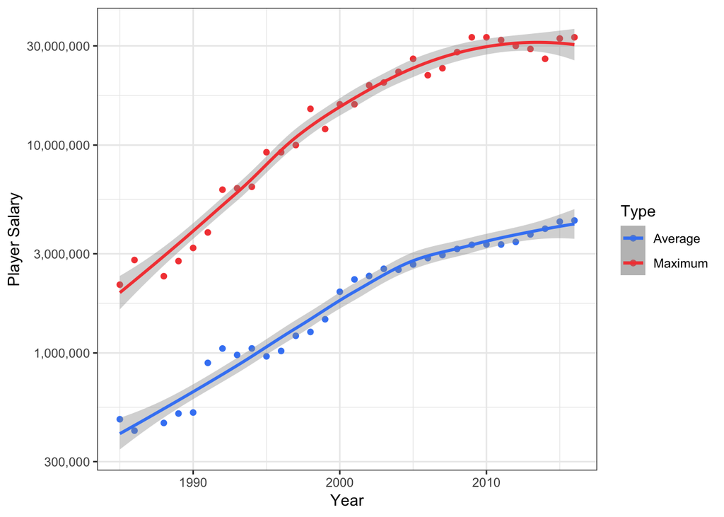

```r
salary_vs_time <- salaries %>%
  group_by(yearID) %>%
  summarize(avg = mean(salary), max = max(salary))

ggplot(data = salary_vs_time) +
  geom_point(aes(x = yearID, y = avg, color = 'Average')) +
  geom_smooth(aes(x = yearID, y = avg, color = 'Average')) +
  geom_point(aes(x = yearID, y = max, color = 'Maximum')) +
  geom_smooth(aes(x = yearID, y = max, color = 'Maximum')) +
  scale_color_manual(values = c('#4286f4', '#f44741')) +
  scale_y_log10(labels = comma) +
  labs(color = 'Type') +
  xlab('Year') +
  ylab('Player Salary')
```

Plot the distributions of annual player salaries from three different years. First is 1985, the start year determined by the original paper. Second is 1998, the year of the last expansion of Major League Baseball in which the 29th and 30th teams were established. Third is 2016, the most recent year for which salary data is available. The red dashed lines denote the maximum annual player salary of each specific year.

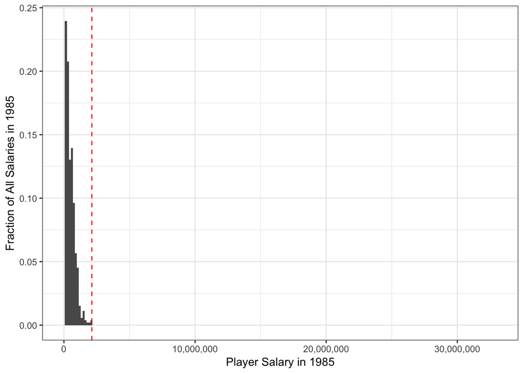

```r
salaries_1985 <- filter(salaries, yearID == 1985)
salaries_1998 <- filter(salaries, yearID == 1998)
salaries_2016 <- filter(salaries, yearID == 2016)

ggplot(data = salaries_1985) +
  geom_histogram(aes(x = salary, y = (..count..) / sum(..count..)), binwidth = 150000) +
  geom_vline(xintercept = max(salaries_1985$salary), color = 'red', linetype = 'dashed') +
  scale_x_continuous(limits = c(0, max(salaries$salary)), labels = comma) +  xlab('Player Salary in 1985') +
  ylab('Fraction of All Salaries in 1985')
```

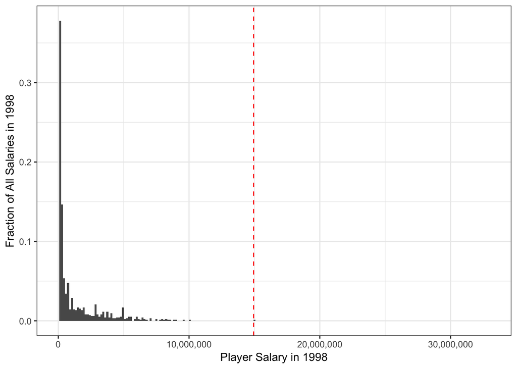

```r
ggplot(data = salaries_1998) +
  geom_histogram(aes(x = salary, y = (..count..) / sum(..count..)), binwidth = 150000) +
  geom_vline(xintercept = max(salaries_1998$salary), color = 'red', linetype = 'dashed') +
  xlim(0, max(salaries$salary)) +
  scale_x_continuous(limits = c(0, max(salaries$salary)), labels = comma) +
  xlab('Player Salary in 1998') +
  ylab('Fraction of All Salaries in 1998')
```

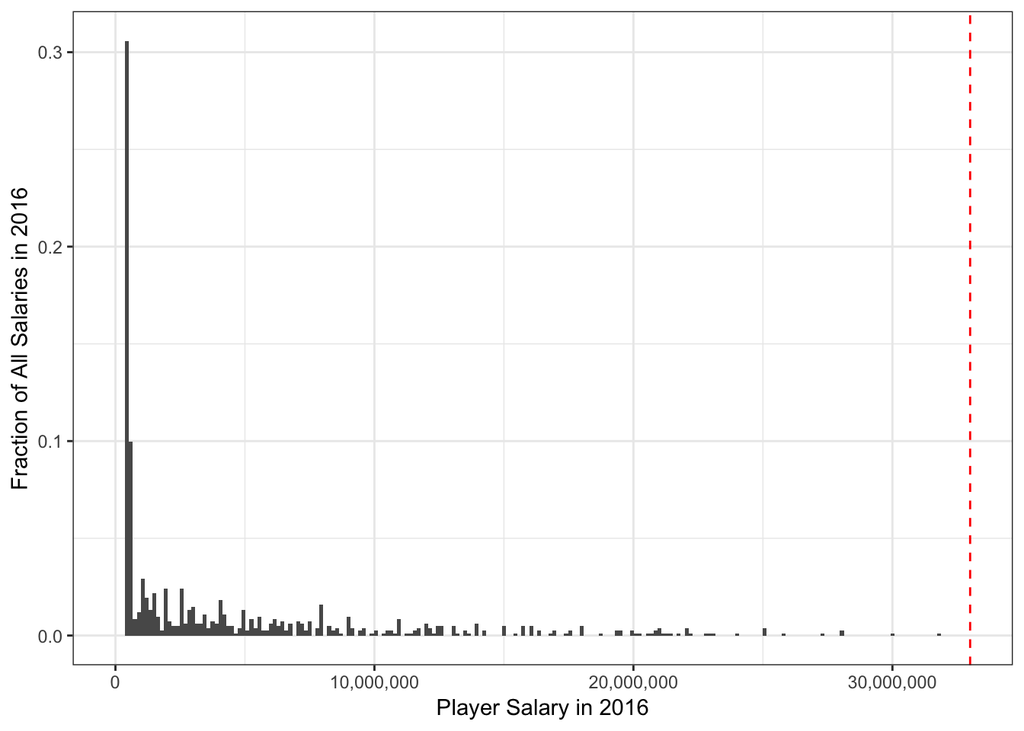

```r
ggplot(data = salaries_2016) +
  geom_histogram(aes(x = salary, y = (..count..) / sum(..count..)), binwidth = 150000) +
  geom_vline(xintercept = max(salaries_2016$salary), color = 'red', linetype = 'dashed') +
  scale_x_continuous(limits = c(0, max(salaries$salary)), labels = comma) +
  xlab('Player Salary in 2016') +
  ylab('Fraction of All Salaries in 2016')
```

The plots suggest that we see longer and longer tails as larger contracts are awarded over time. In 1998, we see that most annual player salaries are clumped at lower values. In 2016, we see that many annual player salaries are near the league minimum $507,500 and few annual player salaries are above $10,000,000.

Plot the relationship between average annual team salary and time. A few key teams are highlighted.

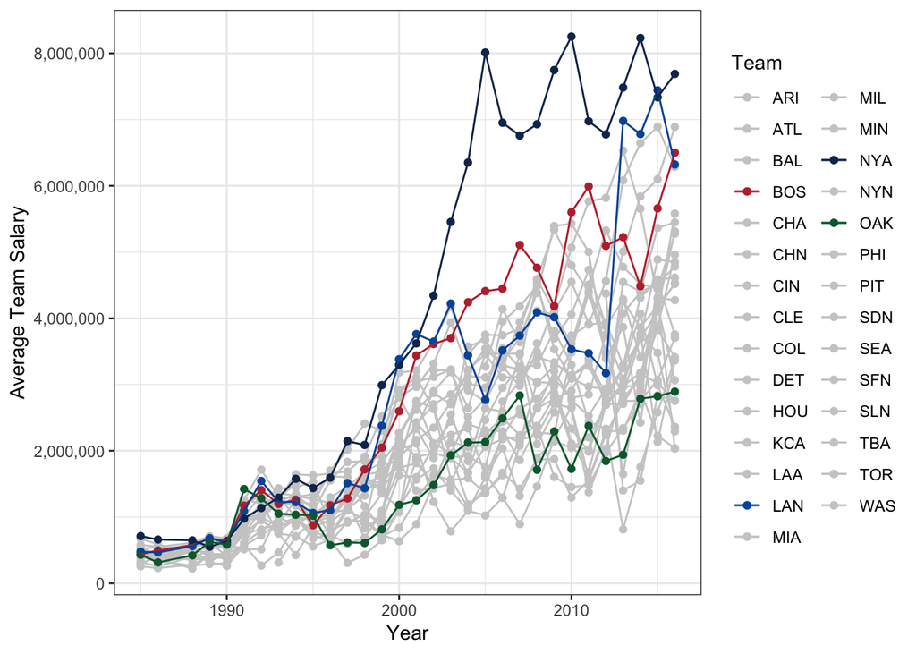

```r
current_teamIDs <- c('ARI', 'ATL', 'BAL', 'BOS', 'CHA', 'CHN', 'CIN', 'CLE', 'COL', 'DET',
                     'HOU', 'KCA', 'LAA', 'LAN', 'MIA', 'MIL', 'MIN', 'NYA', 'NYN', 'OAK',
                     'PHI', 'PIT', 'SDN', 'SEA', 'SFN', 'SLN', 'TBA', 'TEX', 'TOR', 'WAS')
team_colors <- c('#cccccc', '#cccccc', '#cccccc', '#BD3039', '#cccccc',
                 '#cccccc', '#cccccc', '#cccccc', '#cccccc', '#cccccc',
                 '#cccccc', '#cccccc', '#cccccc', '#0157a8', '#cccccc',
                 '#cccccc', '#cccccc', '#11325b', '#cccccc', '#04683b',
                 '#cccccc', '#cccccc', '#cccccc', '#cccccc', '#cccccc',
                 '#cccccc', '#cccccc', '#cccccc', '#cccccc', '#cccccc')
colored_teamIDs <- c('BOS', 'LAN', 'NYA', 'OAK')

team_salary_vs_time <- salaries %>%
  filter(teamID %in% current_teamIDs) %>%
  group_by(yearID, teamID) %>%
  summarize(avg = mean(salary)) %>%
  mutate(flag = teamID %in% colored_teamIDs)

underlay_data <- filter(team_salary_vs_time, !flag)
overlay_data <- filter(team_salary_vs_time, flag)

ggplot() +
  geom_point(data = underlay_data, aes(x = yearID, y = avg, color = teamID)) +
  geom_line(data = underlay_data, aes(x = yearID, y = avg, color = teamID)) +
  geom_point(data = overlay_data, aes(x = yearID, y = avg, color = teamID)) +
  geom_line(data = overlay_data, aes(x = yearID, y = avg, color = teamID)) +
  scale_y_continuous(labels = comma) +
  scale_color_manual(values = team_colors) +
  labs(color = 'Team') +
  xlab('Year') +
  ylab('Average Team Salary')
```

The plot suggests, as is expected, that average annual team salary has increased with time for all teams. Such an increase in expenditure can be attributed to both general inflation and the rise of sports entertainment business. The New York Yankees, the most successful franchise by number of championships, has spent a lot throughout their history. Contrast this with the Oakland Athletics, a franchise which has historically traded for players based on value and has spent relatively little throughout their history.

Plot the relationship between average team HHI and time.

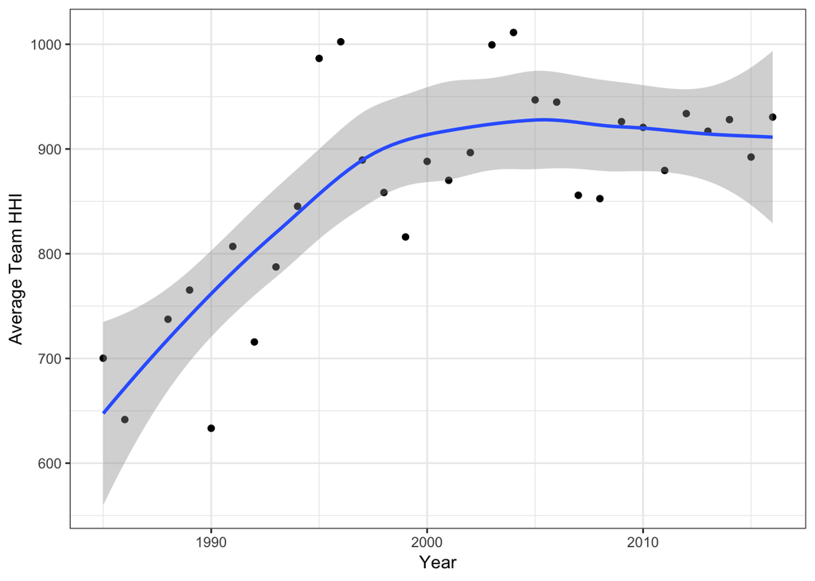

```r
hhi_vs_time <- teams %>%
  group_by(yearID) %>%
  summarize(avg = mean(HHI))

ggplot(data = hhi_vs_time) +
  geom_point(aes(x = yearID, y = avg)) +
  geom_smooth(aes(x = yearID, y = avg)) +
  xlab('Year') +
  ylab('Average Team HHI')
```

Plot the distribution of team HHI using all teams from 1985 to 2016. The dashed vertical lines represent HHI values for teams that won the World Series.

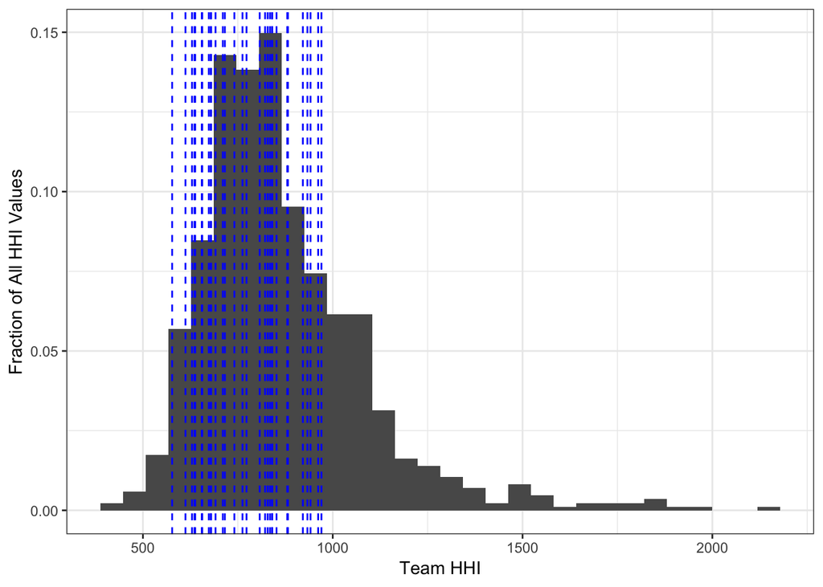

```r
ggplot(data = teams) +
  geom_histogram(aes(x = HHI, y = (..count..) / sum(..count..))) +
  geom_vline(data = filter(teams, WSWin), aes(xintercept = HHI), color = 'blue', linetype = 'dashed') +
  xlab('Team HHI') +
  ylab('Fraction of All HHI Values')
```

The plot suggests that too much intrateam wage disparity can negatively affect a team’s chances of winning the World Series. Namely, all teams that won the World Series between 1985 and 2016 had an intrateam HHI of less than 1,000. For reference, an HHI of less than 1,500 is considered to reflect a competitive marketplace, an HHI between 1,500 and 2,500 is considered to reflect a moderately concentrated marketplace, and an HHI of 2,500 or greater is considered to reflect a highly concentrated marketplace. We hypothesize that this finding is relevant to baseball itself and may not hold when considering other sports. Baseball is a game in which every player must take turns batting in a specified order, unlike basketball in which a single player can control the ball every possession. Hence, the affect of a star player on the outcome of a game is smaller in baseball relative to other sports. In other words, depth of a roster is far more important in baseball. Signing a star player to a huge contract may hurt a team’s ability to offer decent contracts to other important role players, which may ultimately hurt a team’s performance.

Plot the relationship between team HHI and total team salary. The data is split by time period based on the 1993 expansion and the 1998 expansion.

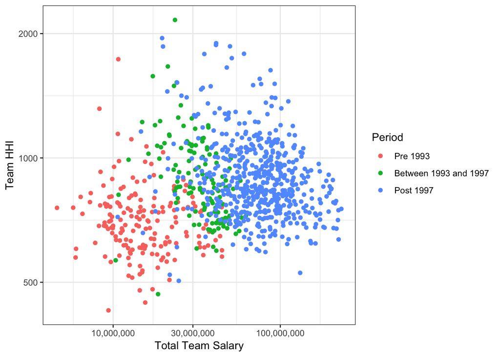

```r
year_to_period <- function(year) {
  if (year <= 1992)
    return('Pre 1993')
  else if (1993 <= year & year <= 1997)
    return('Between 1993 and 1997')
  else
    return('Post 1997')
}

hhi_vs_total_salary <- mutate(teams, period = year_to_period(yearID))
hhi_vs_total_salary$period <- factor(hhi_vs_total_salary$period,
                                     levels = c('Pre 1993', 'Between 1993 and 1997', 'Post 1997'))

ggplot(data = hhi_vs_total_salary) +
  geom_point(aes(x = totalSalaryMil * 1000000, y = HHI, color = period)) +
  scale_x_log10(labels = comma) +
  scale_y_log10() +
  labs(color = 'Period') +
  xlab('Total Team Salary') +
  ylab('Team HHI')
```

The plot suggests some form of clustering between the three time periods. Since total team salary can serve as a proxy for time, we see that the average team HHI exhibits a similar growing and then flattening trend seen in a previous plot.

Compute the Gini coefficient for each team’s salary. For more information, see https://en.wikipedia.org/wiki/Gini_coefficient. The index ranges from 0 to 1 where smaller values represent more equality and larger values represent more inequality.

```r
gini <- salaries %>%
  group_by(yearID, teamID) %>%
  summarize(gini = Gini(salary))
teams <- inner_join(teams, gini)
```

Compute the Atkinson coefficient for each team’s salary. For more information, see https://en.wikipedia.org/wiki/Atkinson_index. The index ranges from 0 to 1 where smaller values represent more equality and larger values represent more inequality.

```r
atkinson <- salaries %>%
  group_by(yearID, teamID) %>%
  summarize(atk = Atkinson(salary))
teams <- inner_join(teams, atkinson)
```

Subset the data after the Gini coefficient and Atkinson coefficient have been computed.

```r
teams_old <- teams %>%
  filter(1985 <= yearID & yearID <= 1998) %>%
  mutate(normalizedYear = yearID - 1985)

teams_new <- teams %>%
  filter(1999 <= yearID & yearID <= 2016) %>%
  mutate(normalizedYear = yearID - 1999)
```

Run the fixed effects regression using the Gini coefficient on data between 1985 and 1998, inclusive.

```r
gini_fixed_old <- lm(formula = winPercentage ~ totalSalaryMil + gini + normalizedYear +
                                               teamID + 0,
                     data = teams_old)
summary(gini_fixed_old)$coefficients[1:3,]
```

```
##                   Estimate Std. Error   t value     Pr(>|t|)
## totalSalaryMil    2.312489  0.4521101  5.114879 5.559085e-07
## gini           -129.827687 58.3962938 -2.223218 2.693371e-02
## normalizedYear   -3.793613  1.8442237 -2.057025 4.053398e-02
```

Run the random effects regression using the Gini coefficient on data between 1985 and 1998, inclusive.

```r
gini_random_old <- lm(formula = winPercentage ~ totalSalaryMil + gini + normalizedYear,
                      data = teams_old)
summary(gini_random_old)$coefficients[1:4,]
```

```
##                   Estimate Std. Error   t value     Pr(>|t|)
## (Intercept)     539.115522 24.3427437 22.146868 1.404711e-67
## totalSalaryMil    2.495248  0.3775998  6.608182 1.532621e-10
## gini           -133.160525 54.5170461 -2.442548 1.510025e-02
## normalizedYear   -4.559438  1.6394568 -2.781066 5.724596e-03
```

Run the fixed effects regression using the Gini coefficient on data between 1999 and 2016, inclusive.

```r
gini_fixed_new <- lm(formula = winPercentage ~ totalSalaryMil + gini + normalizedYear +
                                               teamID + 0,
                     data = teams_new)
summary(gini_fixed_new)$coefficients[1:3,]
```

```
##                    Estimate Std. Error   t value     Pr(>|t|)
## totalSalaryMil    0.6624573  0.1276041  5.191504 3.069387e-07
## gini           -218.5193970 58.0041403 -3.767307 1.852177e-04
## normalizedYear   -2.7481628  0.7167617 -3.834137 1.425403e-04
```

Run the random effects regression using the Gini coefficient on data between 1999 and 2016, inclusive.

```r
gini_random_new <- lm(formula = winPercentage ~ totalSalaryMil + gini + normalizedYear,
                      data = teams_new)
summary(gini_random_new)$coefficients[1:4,]
```

```
##                    Estimate  Std. Error   t value     Pr(>|t|)
## (Intercept)     550.1960765 32.40207090 16.980275 9.795202e-52
## totalSalaryMil    0.8147846  0.08086385 10.076006 6.326317e-22
## gini           -158.9308612 55.31835762 -2.873022 4.232464e-03
## normalizedYear   -3.2653945  0.62553010 -5.220204 2.591533e-07
```

Run the fixed effects regression using the Atkinson coefficient on data between 1985 and 1998, inclusive.

```r
atk_fixed_old <- lm(formula = winPercentage ~ totalSalaryMil + atk + normalizedYear +
                                              teamID + 0,
                    data = teams_old)
summary(atk_fixed_old)$coefficients[1:3,]
```

```
##                   Estimate Std. Error   t value     Pr(>|t|)
## totalSalaryMil    2.376013  0.4504696  5.274524 2.527538e-07
## atk            -179.252498 65.9775739 -2.716870 6.966615e-03
## normalizedYear   -3.413854  1.8123452 -1.883667 6.056128e-02
```

Run the random effects regression using the Atkinson coefficient on data between 1985 and 1998, inclusive.

```r
atk_random_old <- lm(formula = winPercentage ~ totalSalaryMil + atk + normalizedYear,
                     data = teams_old)
summary(atk_random_old)$coefficients[1:4,]
```

```
##                   Estimate Std. Error   t value      Pr(>|t|)
## (Intercept)     509.553006 11.7544621 43.349751 1.975329e-139
## totalSalaryMil    2.555104  0.3759984  6.795518  4.948012e-11
## atk            -181.545622 61.0995554 -2.971308  3.179705e-03
## normalizedYear   -4.188912  1.6071160 -2.606478  9.556548e-03
```

Run the fixed effects regression using the Atkinson coefficient on data between 1999 and 2016, inclusive.

```r
atk_fixed_new <- lm(formula = winPercentage ~ totalSalaryMil + atk + normalizedYear +
                                              teamID + 0,
                    data = teams_new)
summary(atk_fixed_new)$coefficients[1:3,]
```

```
##                    Estimate Std. Error   t value     Pr(>|t|)
## totalSalaryMil    0.6943805  0.1274283  5.449185 8.049458e-08
## atk            -267.2160401 60.5183651 -4.415454 1.242698e-05
## normalizedYear   -2.8583544  0.7142924 -4.001659 7.268982e-05
```

Run the random effects regression using the Atkinson coefficient on data between 1999 and 2016, inclusive.

```r
atk_random_new <- lm(formula = winPercentage ~ totalSalaryMil + atk + normalizedYear,
                     data = teams_new)
summary(atk_random_new)$coefficients[1:4,]
```

```
##                    Estimate  Std. Error   t value      Pr(>|t|)
## (Intercept)     512.1999193 17.31125767 29.587678 2.179218e-113
## totalSalaryMil    0.8479434  0.08182447 10.362956  5.387417e-23
## atk            -193.0102061 57.91250941 -3.332790  9.212586e-04
## normalizedYear   -3.3980916  0.62691299 -5.420356  9.131764e-08
```

With both the Gini and Atkinson coefficient used in place of HHI, our regressions are very similar to that of our replications, our extensions, and the original work. Our results are consistent for both coefficients over all four model cases: 1985 to 1998 fixed effects, 1985 to 1998 random effects, 1999 to 2016 fixed effects, and 1999 to 2016 random effects. Specifically, the signs of the coefficients remain the same, while the magnitude of the coefficients for both total team salary and year remain approximately the same. The coefficients on the Gini index and the Atkinson index are much bigger because the value of these indices range between 0 and 1 as opposed to the values of HHI, which range between 0 and 10,000. Again, for all three indices, lower values represent more equality and higher values represent more inequality. The fact that we see very similar magnitudes of coefficients for the non-index variables is important, because it suggests that the HHI metric used in the original paper is equally acceptable as compared to the commonly used Gini index or Atkinson index.

Run 5-fold cross validated linear regression to generate a validation error and analyze predictive performance. Here we include all teams from 1985 to 2016 as potential training data points. We use the fixed effects model since all teams serve as a training data point at least 4 times during the train and validate process. As previously discussed, the individual regression coefficients of the different inequality indices have the same predictive or explanatory power despite the differences in magnitude. We choose to use HHI here.

```r
num_folds <- 5
num_rows <- nrow(teams)
shuffle_idx <- sample(1:num_rows, num_rows, replace = FALSE)

teams_k_fold <- teams[shuffle_idx,] %>%
  ungroup() %>%
  mutate(fold = (row_number() %% num_folds) + 1) %>%
  mutate(normalizedYear = yearID - 1985)

validate_err <- c()
train_err <- c()
for (f in 1:num_folds) {
  curr_train <- filter(teams_k_fold, fold != f)
  model <- lm(formula = winPercentage ~ totalSalaryMil + HHI + normalizedYear + teamID + 0,
              data = curr_train)
  train_err[f] <- sqrt(mean((predict(model, curr_train) - curr_train$winPercentage) ^ 2))

  curr_validate <- filter(teams_k_fold, fold == f)
  validate_err[f] <- sqrt(mean((predict(model, curr_validate) - curr_validate$winPercentage) ^ 2))
}

avg_validate_err <- mean(validate_err)
se_validate_err <- sd(validate_err) / sqrt(num_folds)

avg_train_err <- mean(train_err)
se_train_err <- sd(train_err) / sqrt(num_folds)

print(avg_validate_err)
```

```
## [1] 64.5121
```

```r
print(se_validate_err)
```

```
## [1] 1.500566
```

```r
print(avg_train_err)
```

```
## [1] 61.27118
```

```r
print(se_train_err)
```

```
## [1] 0.331831
```

```r
teams_pre_1997 <- teams %>%
  filter(yearID <= 1997) %>%
  mutate(normalizedYear = yearID - 1985)
teams_post_1998 <- teams %>%
  filter(yearID >= 1998) %>%
  mutate(normalizedYear = yearID - 1985)

time_model <- lm(formula = winPercentage ~ totalSalaryMil + HHI + normalizedYear,
                 data = teams_pre_1997)
time_train_err <- sqrt(mean((predict(model, teams_pre_1997) - teams_pre_1997$winPercentage) ^ 2))
time_validate_err <- sqrt(mean((predict(model, teams_post_1998) - teams_post_1998$winPercentage) ^ 2))

print(time_train_err)
```

```
## [1] 62.34419
```

```r
print(time_validate_err)
```

```
## [1] 61.5418
```

# 4 Postface